# Analisi del Darkweb

Andrea D’Orazio

2026-01-29

# Introduzione

Il dark web, noto anche come onionweb, si riferisce all’insieme dei domini accessibili sotto il pseudo–top-level domain .onion. A differenza del World Wide Web, il dark web è caratterizzato da meccanismi di anonimato e protezione della privacy che rendono difficile tracciare l’origine geografica delle comunicazioni e l’identità dei soggetti coinvolti.

L’obiettivo di questo progetto è condurre un’analisi strutturale di una rete del dark web utilizzando strumenti e metodologie della network science, così come affrontati durante il corso. L’analisi adotta un approccio puramente topologico e non considera il contenuto o la natura delle attività associate ai domini analizzati.

Il dataset oggetto di studio rappresenta una rete diretta di domini del dark web, in cui ciascun nodo corrisponde a un servizio onion e ogni arco diretto rappresenta un collegamento ipertestuale tra due domini distinti. Questa rappresentazione consente di analizzare sia proprietà locali, come le misure di centralità e di potere strutturale dei nodi, sia proprietà globali, quali la connettività, l’organizzazione della rete e la sua resilienza a guasti o attacchi mirati.

Il dataset utilizzato in questo studio è stato reperito dal repository Index of Complex Networks (ICON) (https://icon.colorado.edu ). Il grafo relativo alla rete di domini del dark web è stato scaricato dal link: https://santafe.edu/~aaronc/shared/darkweb_2017.zip

## Domande di Ricerca

Questa analisi mira a rispondere alle seguenti domande di ricerca:

**RQ1:** La rete del dark web presenta un’elevata presenza di nodi isolati e una struttura complessivamente frammentata in più componenti?

**RQ2:** La connettività della rete è sostenuta da pochi nodi altamente centrali?

**RQ3:** Esistono nodi che svolgono un ruolo critico di intermediazione nella rete? Se sì, quali sono?

**RQ4:** Il darkweb mostra caratteristiche di small-world o scale-free network nonostante la sua sparsità?

**RQ5:** La rete è più vulnerabile a guasti casuali o ad attacchi mirati sui nodi centrali?

# Setup e Caricamento Dati

## Caricamento Librerie

```r
library(igraph)
library(tidygraph)
library(ggraph)
library(tidyverse)
library(knitr)
library(kableExtra)
library(scales)
library(gridExtra)
library(poweRlaw)
```

## Caricamento Dati

```r
# Carica nodi
nodes <- read.csv("darkweb-nodes.txt",
                  sep = ";",
                  header = TRUE,
                  stringsAsFactors = FALSE)

# Carica archi
edges <- read.csv("darkweb-edges.txt",
                  sep = ";",
                  header = TRUE,
                  stringsAsFactors = FALSE)

# Mostra informazioni di base
cat("Dataset caricato con successo!\n")
```

```
## Dataset caricato con successo!
```

```r
cat("Numero di nodi:", nrow(nodes), "\n")
```

```
## Numero di nodi: 7178
```

```r
cat("Numero di archi:", nrow(edges), "\n")
```

```
## Numero di archi: 25104
```

## Creazione Oggetti Network

```r
# Crea network igraph dalla lista di archi
g <- graph_from_data_frame(d = edges[, c("Source", "Target", "Weight")],
                           vertices = nodes,
                           directed = TRUE)

# Crea oggetto tidygraph
tg <- as_tbl_graph(g, directed = TRUE)

# Proprietà di base del network
cat("Diretto:", is_directed(g), "\n")
```

```
## Diretto: TRUE
```

```r
cat("Pesato:", is_weighted(g), "\n")
```

```
## Pesato: FALSE
```

```r
cat("Numero di vertici:", vcount(g), "\n")
```

```
## Numero di vertici: 7178
```

```r
cat("Numero di archi:", ecount(g), "\n")
```

```
## Numero di archi: 25104
```

```r
cat("Densità:", edge_density(g), "\n")
```

```
## Densità: 0.0004873001
```

# RQ1: La rete del dark web presenta un’elevata presenza di nodi isolati e una struttura complessivamente frammentata in più componenti?

## Analisi Out-Degree

```r
# Calcola out-degrees
out_degrees <- degree(g, mode = "out")

# Conta nodi con out-degree = 0
nodes_no_outlinks <- sum(out_degrees == 0)
prop_no_outlinks <- nodes_no_outlinks / vcount(g) * 100

cat("I nodi con out-degree = 0 sono ", nodes_no_outlinks, "\n")
```

```
## I nodi con out-degree = 0 sono  6242
```

```r
cat("Percentuale di nodi senza link in uscita:", round(prop_no_outlinks, 2), "%\n")
```

```
## Percentuale di nodi senza link in uscita: 86.96 %
```

```r
cat("Media out-degree:", round(mean(out_degrees), 2), "\n")
```

```
## Media out-degree: 3.5
```

```r
cat("Mediana out-degree:", median(out_degrees), "\n")
```

```
## Mediana out-degree: 0
```

```r
cat("Max out-degree:", max(out_degrees), "\n")
```

```
## Max out-degree: 5582
```

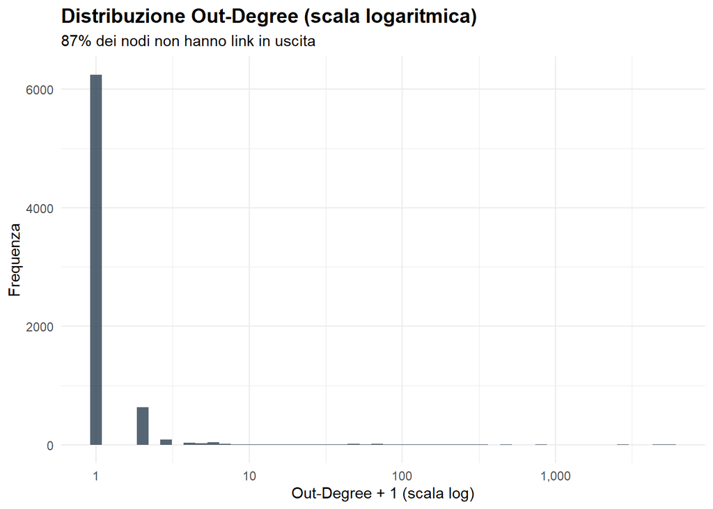

```r
# Grafico distribuzione out-degree
out_degree_df <- data.frame(out_degree = out_degrees)

p1 <- ggplot(out_degree_df, aes(x = out_degree + 1)) +
  geom_histogram(bins = 50, fill = "#2C3E50", alpha = 0.8) +
  scale_x_log10(labels = comma) +
  theme_minimal() +
  labs(title = "Distribuzione Out-Degree (scala logaritmica)",
       subtitle = paste0(round(prop_no_outlinks, 1), "% dei nodi non hanno link in uscita"),
       x = "Out-Degree + 1 (scala log)",
       y = "Frequenza") +
  theme(plot.title = element_text(face = "bold", size = 14))

print(p1)
```

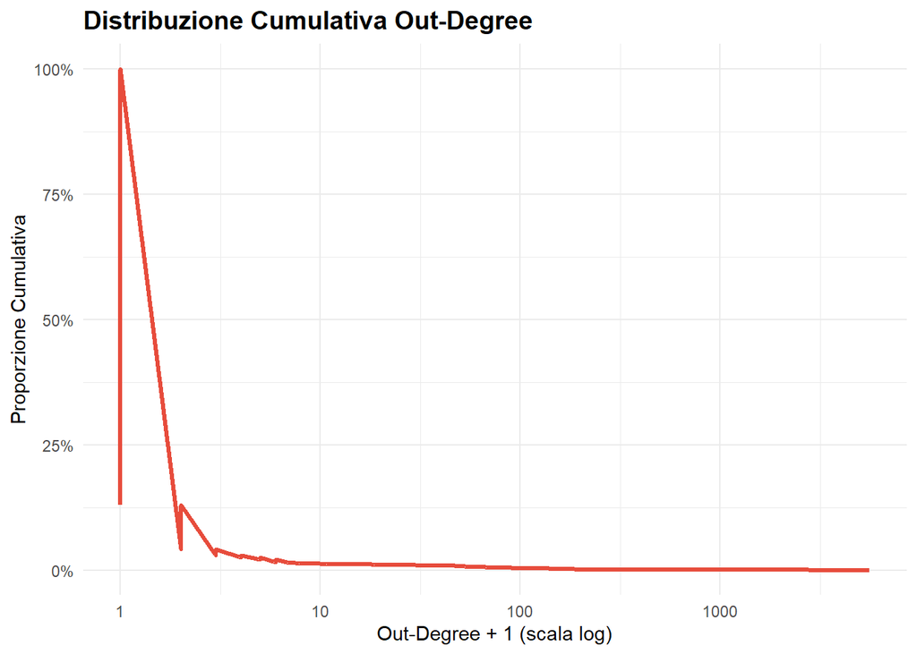

```r
# Distribuzione cumulativa
out_degree_sorted <- sort(out_degrees, decreasing = TRUE)
cumulative_prop <- (1:length(out_degree_sorted)) / length(out_degree_sorted)

p2 <- ggplot(data.frame(degree = out_degree_sorted, cum_prop = cumulative_prop),
             aes(x = degree + 1, y = cum_prop)) +
  geom_line(color = "#E74C3C", linewidth = 1.2) +
  scale_x_log10() +
  scale_y_continuous(labels = percent) +
  theme_minimal() +
  labs(title = "Distribuzione Cumulativa Out-Degree",
       x = "Out-Degree + 1 (scala log)",
       y = "Proporzione Cumulativa") +
  theme(plot.title = element_text(face = "bold", size = 14))

print(p2)
```

## Analisi In-Degree

```r
# Calcola in-degrees
in_degrees <- degree(g, mode = "in")

cat("Media in-degree:", round(mean(in_degrees), 2), "\n")
```

```
## Media in-degree: 3.5
```

```r
cat("Mediana in-degree:", median(in_degrees), "\n")
```

```
## Mediana in-degree: 3
```

```r
cat("Max in-degree:", max(in_degrees), "\n")
```

```
## Max in-degree: 209
```

```r
cat("Nodi con in-degree = 0:", sum(in_degrees == 0), "\n")
```

```
## Nodi con in-degree = 0: 0
```

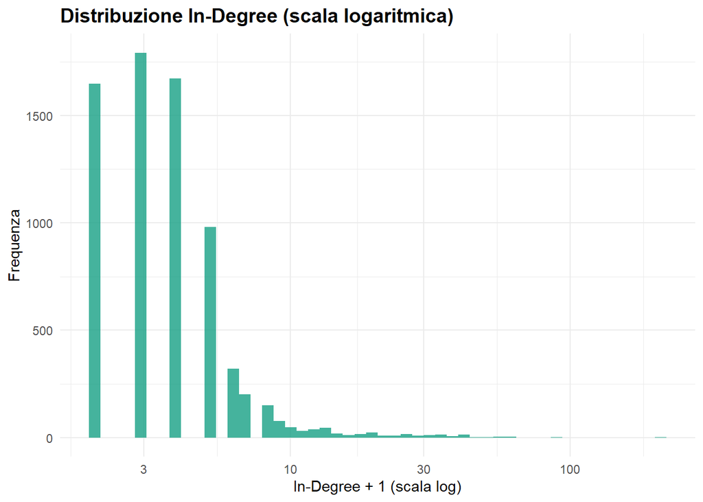

```r
# Grafico distribuzione in-degree
in_degree_df <- data.frame(in_degree = in_degrees)

p3 <- ggplot(in_degree_df, aes(x = in_degree + 1)) +
  geom_histogram(bins = 50, fill = "#16A085", alpha = 0.8) +
  scale_x_log10(labels = comma) +
  theme_minimal() +
  labs(title = "Distribuzione In-Degree (scala logaritmica)",
       x = "In-Degree + 1 (scala log)",
       y = "Frequenza") +
  theme(plot.title = element_text(face = "bold", size = 14))

print(p3)
```